# **NHÓM 7 DỮ LIỆU VỀ TIỂU ĐƯỜNG**

### PREDICTING DIABETES using Decision Tree model

#### Ma trận tương quan

[figure not shown]

```r
#install.packages("corrgram")
library(corrgram)
corrgram(diabetes_filter)
```

Xét biểu đồ tương quan, ta thấy:  
- Pregnancies và Age tương quan cao  
- SkinThickness và Insulin tương quan cao

Do đó: Khi xây dựng mô hình dự đoán, với mỗi cặp thuộc tính, chỉ sử dụng 1 trong 2 để hạn chế tình trạng đa cộng tuyến (multicollinearity)

### MÔ HÌNH CÂY QUYẾT ĐỊNH

#### Chia tập dữ liệu thành 2 tập train và test

```r
library(caret)
```

Chi tập dữ liệu thành 2 phần, tập train để xây dựng mô hình và tập test để kiểm tra mô hình

```r
set.seed(1)
split <- createDataPartition(diabetes_filter$Outcome,p = 0.75,list = FALSE)
dfTrain <- diabetes_filter[split,]
dfTest <- diabetes_filter[-split,]
```

```r
head(dfTrain)
```

```
##   Pregnancies Glucose BloodPressure SkinThickness Insulin  BMI
## 1           6     148            72            35       0 33.6
## 2           1      85            66            29       0 26.6
## 3           8     183            64             0       0 23.3
## 4           1      89            66            23      94 28.1
## 5           0     137            40            35     168 43.1
## 6           5     116            74             0       0 25.6
##   DiabetesPedigreeFunction Age Outcome
## 1                    0.627  50       1
## 2                    0.351  31       0
## 3                    0.672  32       1
## 4                    0.167  21       0
## 5                    2.288  33       1
## 6                    0.201  30       0
```

```r
head(dfTest)
```

```
##    Pregnancies Glucose BloodPressure SkinThickness Insulin  BMI
## 9            2     197            70            45     543 30.5
## 10           8     125            96             0       0  0.0
## 12          10     168            74             0       0 38.0
## 13          10     139            80             0       0 27.1
## 14           1     189            60            23     846 30.1
## 23           7     196            90             0       0 39.8
##    DiabetesPedigreeFunction Age Outcome
## 9                     0.158  53       1
## 10                    0.232  54       1
## 12                    0.537  34       1
## 13                    1.441  57       0
## 14                    0.398  59       1
## 23                    0.451  41       1
```

#### Hàm kiểm tra mô hình

Xây dựng các hàm kiểm tra kết quả của mô hình

Hàm xây dựng ma trận nhầm lẫn để xem kết quả dự đoán và tính độ chính xác bằng ma trận nhầm lẫn

```r
# Dùng ma trận nhầm lẫn
accuracy <- function() {
  predictions <- predict(model, newdata = dfTest, type = "class")

  # So sánh giữa giá trị dự đoán và giá trị thực tế
  confusion_matrix <- table(predictions, dfTest$Outcome)
  print(confusion_matrix)

  # Tính toán độ chính xác từ ma trận nhầm lẫn
  accuracy <- sum(diag(confusion_matrix)) / sum(confusion_matrix)
  return (accuracy)
}
```

Hàm tính độ chính xác, độ nhạy và độ đặc hiệu của mô hình

```r
thongso <- function() {
  predictions <- predict(model, newdata = dfTest, type = "class")
  confusion_matrix <- table(predictions, dfTest$Outcome)
  TP <- confusion_matrix[2, 2]  # True Positive
  TN <- confusion_matrix[1, 1]  # True Negative
  FP <- confusion_matrix[1, 2]  # False Positive
  FN <- confusion_matrix[2, 1]  # False Negative

  Accuracy<-(TP+TN)/(TP+TN+FP+FN)
  cat("Độ chính xác:",Accuracy,"\n")

  #trong số bệnh nhân thực tế bị bệnh tiểu đường,bao nhiêu phần trăm được dự báo bị bệnh
  Sensitivity<-TP/(TP+FN)
  cat("Độ nhạy:",Sensitivity,"\n")
  #trong số bệnh nhân thực tế không bị bệnh, bao nhiêu phần trăm được dự báo không bị bệnh

  Specificity<-TN/(TN+FP)
  cat("Độ đặc hiệu",Specificity)
}
```

#### Xây dựng mô hình cây quyết định

##### Mô hình cây quyết định

Xây dựng mô hình cây quyết định ban đầu. Với thuộc tính mục tiêu là Outcome, và biến thành phần và các thuộc tính còn lại của tập dữ liệu

```r
# Huấn luyện mô hình cây quyết định
library(rpart)
model <- rpart(Outcome ~ Pregnancies + Glucose + BloodPressure + SkinThickness + Insulin + BMI + DiabetesPedigreeFunction + Age, data = dfTrain, method = "class")

# In cây quyết định
print(model)
```

```
## n= 570
##
## node), split, n, loss, yval, (yprob)
##       * denotes terminal node
##
##   1) root 570 202 0 (0.64561404 0.35438596)
##     2) Glucose< 127.5 369  75 0 (0.79674797 0.20325203)
##       4) Age< 29.5 216  23 0 (0.89351852 0.10648148) *
##       5) Age>=29.5 153  52 0 (0.66013072 0.33986928)
##        10) BMI< 26.95 33   1 0 (0.96969697 0.03030303) *
##        11) BMI>=26.95 120  51 0 (0.57500000 0.42500000)
##          22) Glucose< 106.5 62  17 0 (0.72580645 0.27419355) *
##          23) Glucose>=106.5 58  24 1 (0.41379310 0.58620690)
##            46) BloodPressure>=85 12   3 0 (0.75000000 0.25000000) *
##            47) BloodPressure< 85 46  15 1 (0.32608696 0.67391304)
##              94) SkinThickness>=13.5 27  12 1 (0.44444444 0.55555556)
##               188) DiabetesPedigreeFunction< 0.5485 15   4 0 (0.73333333 0.26666667) *
##               189) DiabetesPedigreeFunction>=0.5485 12   1 1 (0.08333333 0.91666667) *
##              95) SkinThickness< 13.5 19   3 1 (0.15789474 0.84210526) *
##     3) Glucose>=127.5 201  74 1 (0.36815920 0.63184080)
##       6) BMI< 30.2 54  20 0 (0.62962963 0.37037037)
##        12) Age>=56 10   0 0 (1.00000000 0.00000000) *
##        13) Age< 56 44  20 0 (0.54545455 0.45454545)
##          26) Age< 26.5 14   2 0 (0.85714286 0.14285714) *
##          27) Age>=26.5 30  12 1 (0.40000000 0.60000000) *
##       7) BMI>=30.2 147  40 1 (0.27210884 0.72789116)
##        14) Glucose< 157.5 88  33 1 (0.37500000 0.62500000)
##          28) BMI< 41.65 69  32 1 (0.46376812 0.53623188)
##            56) Age< 31 26   7 0 (0.73076923 0.26923077) *
##            57) Age>=31 43  13 1 (0.30232558 0.69767442) *
##          29) BMI>=41.65 19   1 1 (0.05263158 0.94736842) *
##        15) Glucose>=157.5 59   7 1 (0.11864407 0.88135593) *
```

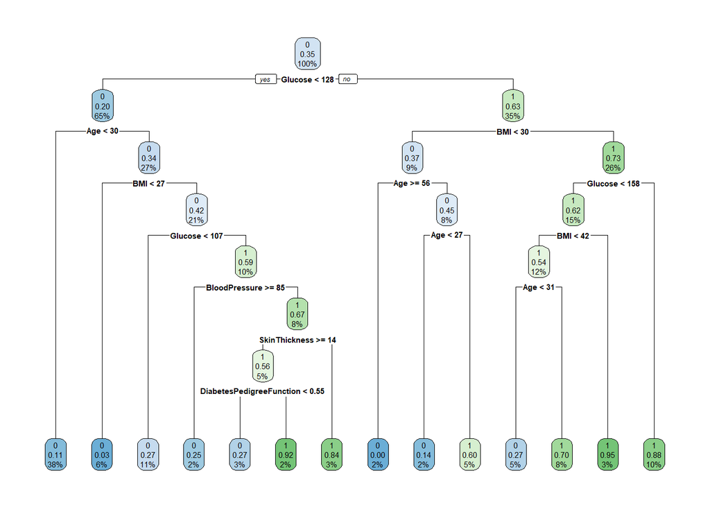

```r
# Biểu đồ cây quyết định
library(rpart.plot)
rpart.plot(model)
```

Xem kết quả dự đoán từ mô hình cây quyết định

```r
thongso()
```

```
## Độ chính xác: 0.7473684
## Độ nhạy: 0.6206897
## Độ đặc hiệu 0.8030303
```

##### Xem độ quan trọng của các thuộc tính trong mô hình

Quan sát biểu đồ mức độ quan trọng của các thuộc tính trong mô hình để thay đổi thuộc tính thành phần

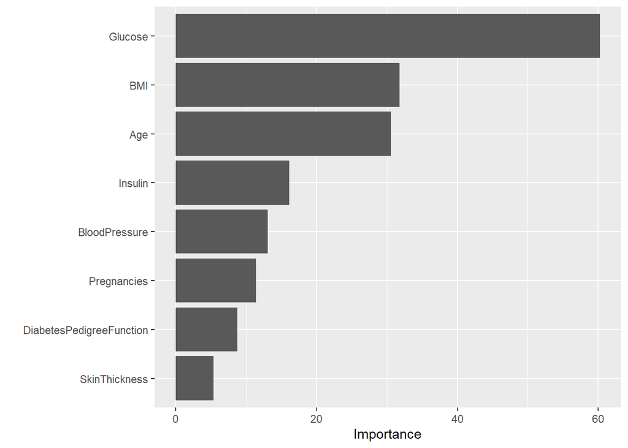

```r
library(vip)
var_importance <- vip::vip(model, num_features = 10)
print(var_importance)
```

Quan sát tác động của của các thuộc tính riêng lẻ lên quyết định của mô hình

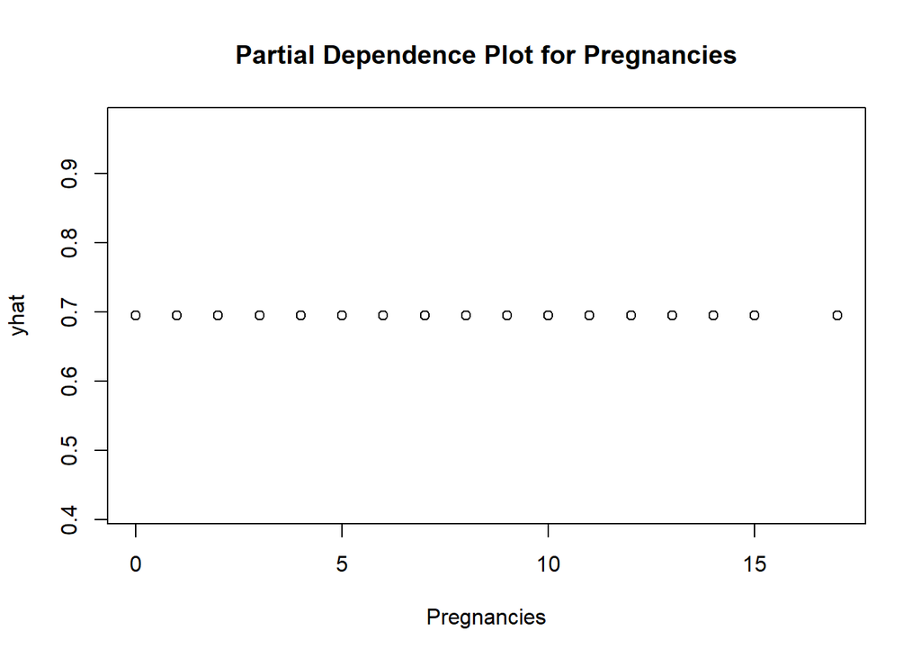

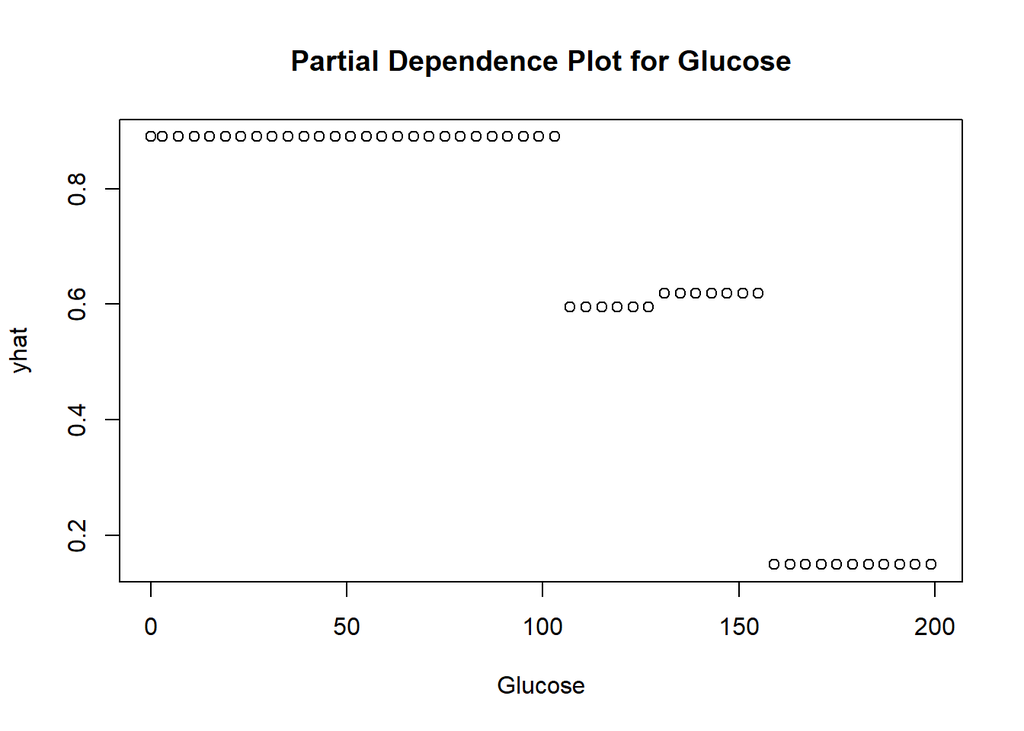

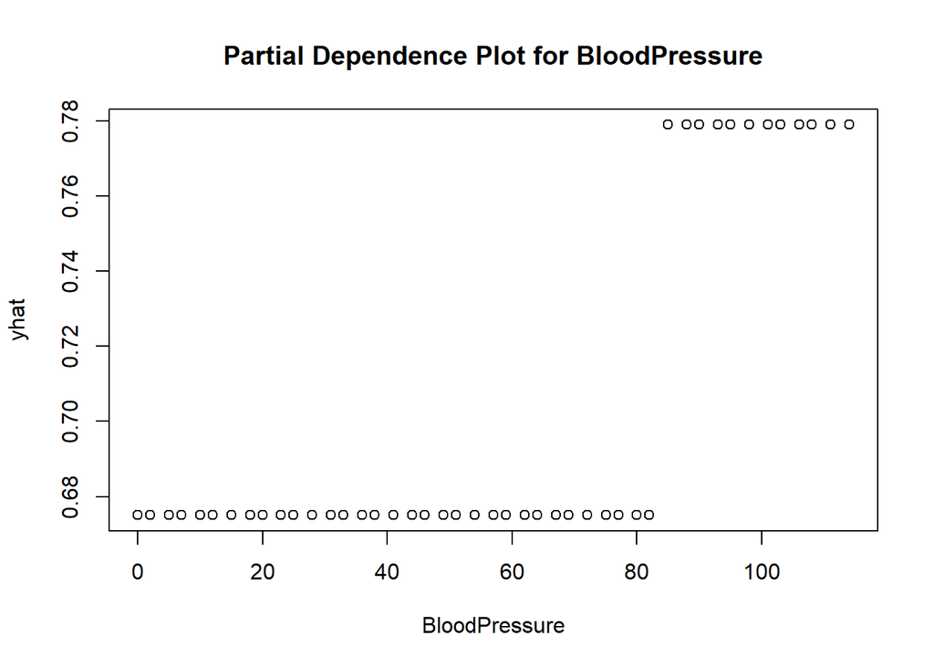

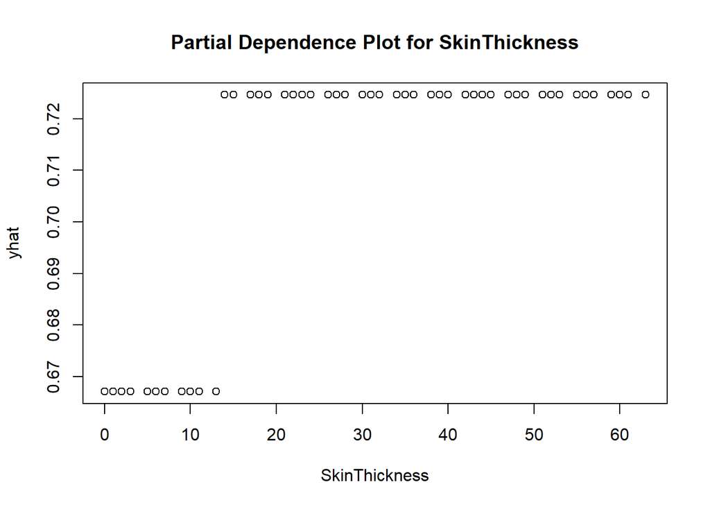

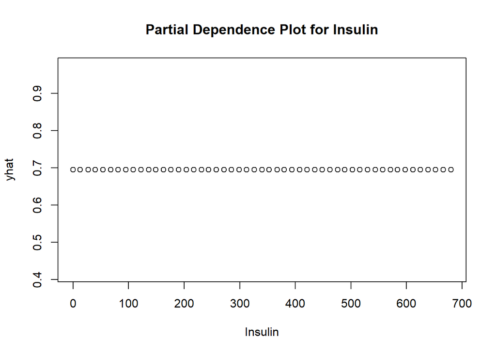

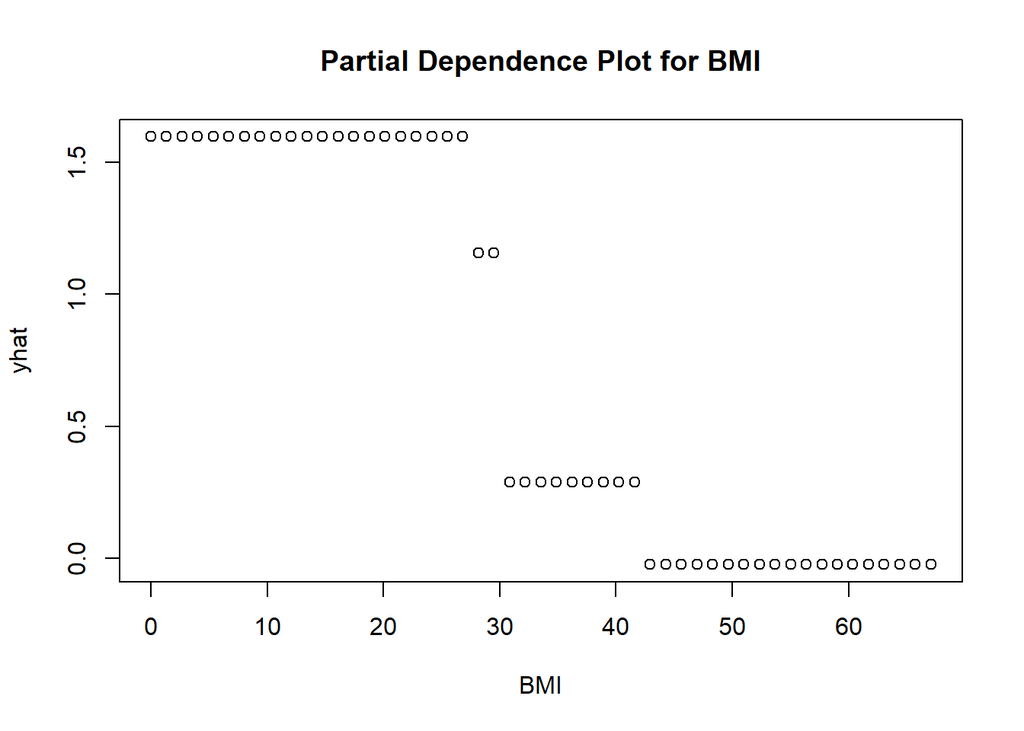

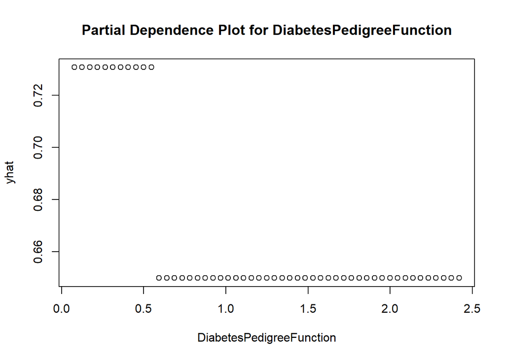

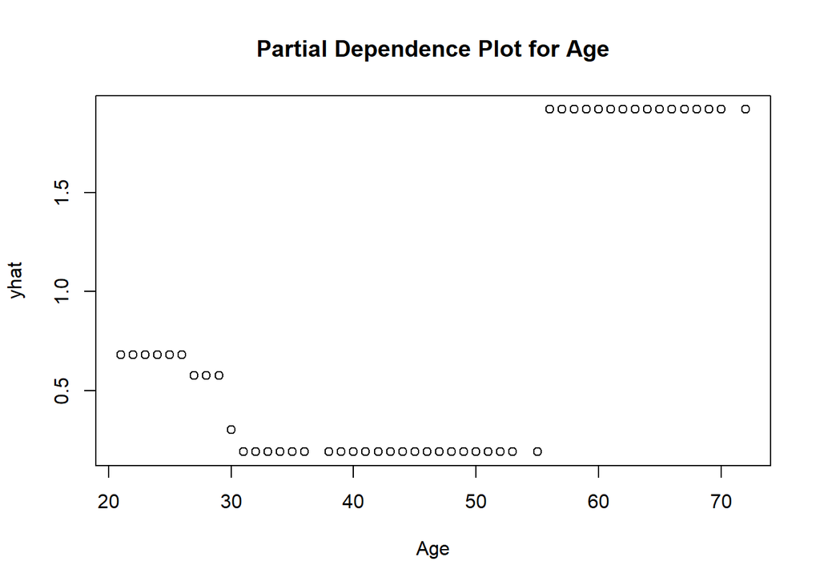

```r
library(pdp)
library(ggplot2)

# Lặp qua từng cột trong dfTrain (loại bỏ cột mục tiêu)
for (col in names(dfTrain)[-ncol(dfTrain)]) {
  # Tạo Partial Dependence Plot cho từng cột và lưu vào biến pdp_plot
  pdp_plot <- partial(model, pred.var = col)

  # Tạo biểu đồ Partial Dependence Plot và hiển thị
  plot(pdp_plot, main = paste("Partial Dependence Plot for", col))
}
```

##### Loại bỏ các thuộc tính trên (Pregnancies, SkinThickness, Insulin)

Loại bỏ thuộc tính Insulin, SkinThickness và Pregnancies thấy mô hình tăng độ chính xác, độ nhạy và độ đặc hiệu. Quyết định chấp nhận mô hình với độ chính xác ~76% và độ nhạy ~0.64, độ đặc hiệu ~0.82

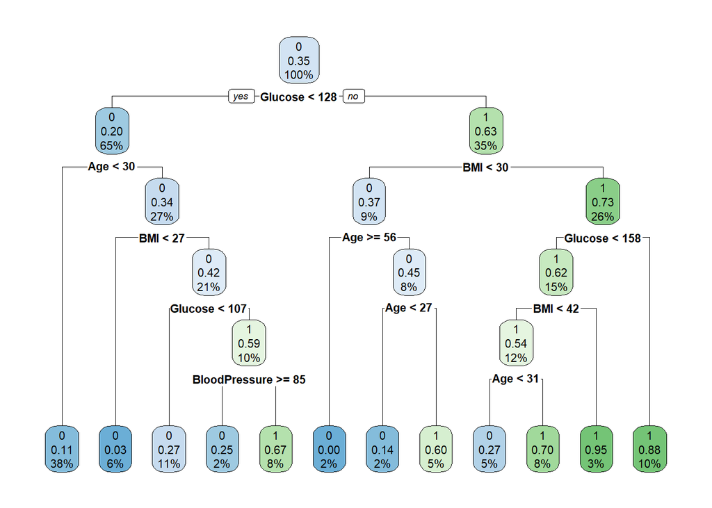

```r
model <- rpart(Outcome ~ Glucose + BloodPressure + BMI + DiabetesPedigreeFunction + Age, data = dfTrain, method = "class")
rpart.plot(model)
```

Thông số của mô hình sau khi loại bỏ các thuộc tính có độ quan trọng thấp

```r
accuracy()
```

```
##
## predictions   0   1
##           0 106  23
##           1  22  39
```

```
## [1] 0.7631579
```

```r
thongso()
```

```
## Độ chính xác: 0.7631579
## Độ nhạy: 0.6393443
## Độ đặc hiệu 0.8217054
```

##### Trích xuất các luật từ cây quyết định

Xem quy luật của mô hình cây quyết định

```r
rules <- rpart.rules(model)
print(rules)
```

```
##  Outcome
##     0.00 when Glucose >=        128 & BMI <  30       & Age >=       56
##     0.03 when Glucose <  128        & BMI <  27       & Age >=       30
##     0.11 when Glucose <  128                          & Age <  30
##     0.14 when Glucose >=        128 & BMI <  30       & Age <  27
##     0.25 when Glucose is 107 to 128 & BMI >=       27 & Age >=       30 & BloodPressure >= 85
##     0.27 when Glucose is 128 to 158 & BMI is 30 to 42 & Age <  31
##     0.27 when Glucose <  107        & BMI >=       27 & Age >=       30
##     0.60 when Glucose >=        128 & BMI <  30       & Age is 27 to 56
##     0.67 when Glucose is 107 to 128 & BMI >=       27 & Age >=       30 & BloodPressure <  85
##     0.70 when Glucose is 128 to 158 & BMI is 30 to 42 & Age >=       31
##     0.88 when Glucose >=        158 & BMI >=       30
##     0.95 when Glucose is 128 to 158 & BMI >=       42
```

#### So sánh hiệu suất của mô hình hồi quy logistic với mô hình cây quyết định ta thấy :

-> *Hai mô hình cho thấy độ chính xác và độ đặc hiệu khá giống nhau* -> *Nhưng độ nhạy lại khác nhau.Mô hình hồi quy logistic có độ nhạy lớn hơn cho thấy mô hình nhận dạng các trường hợp bị bệnh chính xác hơn*

-> *Đối với các bài toán dự báo bệnh thì độ nhạy lớn sẽ tốt hơn. Điều này là do độ nhạy là thước đo về mức độ tốt của mô hình trong việc dự đoán các trường hợp dương tính. Trong các bài toán dự báo bệnh, việc xác định chính xác các trường hợp mắc bệnh là rất quan trọng. Nếu mô hình có độ nhạy thấp, thì mô hình sẽ có xu hướng bỏ sót các trường hợp mắc bệnh, điều này có thể dẫn đến việc điều trị sai hoặc không điều trị.*

### Classifying the categories of Mass (BMI) using Random Forest model

The World Health Organization (WHO) classifies adults based on the following BMI ranges:

- Underweight: < 18.5 kg/m^2
- Normal weight: 18.5 - 24.9 kg/m^2
- Overweight: 25.0 - 29.9 kg/m^2
- Obese: ≥ 30.0 kg/m^2

```r
library(ggplot2)
```

```r
diabetes_filter$BMI_Category <- cut(diabetes_filter$BMI,
                             breaks = c(-Inf, 18.5, 24.9, 29.9, Inf),
                             labels = c("Underweight", "Normal", "Overweight", "Obese"))
```

*Trực quan phân bố của từng loại cân nặng*

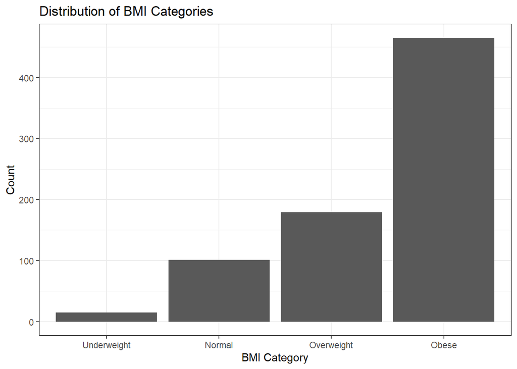

```r
ggplot(diabetes_filter, aes(x = BMI_Category)) +
  geom_bar(stat = "count") +
  labs(title = "Distribution of BMI Categories", x = "BMI Category", y = "Count") +
  theme_bw()
```

*Tạo một dataframe bản sao với BMI_Category đã được số hóa*

```r
num_diabetes <- diabetes_filter
num_diabetes$BMI_Category <- as.integer(num_diabetes$BMI_Category)
str(num_diabetes)
```

```
## 'data.frame':    760 obs. of  10 variables:
##  $ Pregnancies             : int  6 1 8 1 0 5 3 10 2 8 ...
##  $ Glucose                 : int  148 85 183 89 137 116 78 115 197 125 ...
##  $ BloodPressure           : int  72 66 64 66 40 74 50 0 70 96 ...
##  $ SkinThickness           : int  35 29 0 23 35 0 32 0 45 0 ...
##  $ Insulin                 : int  0 0 0 94 168 0 88 0 543 0 ...
##  $ BMI                     : num  33.6 26.6 23.3 28.1 43.1 25.6 31 35.3 30.5 0 ...
##  $ DiabetesPedigreeFunction: num  0.627 0.351 0.672 0.167 2.288 ...
##  $ Age                     : int  50 31 32 21 33 30 26 29 53 54 ...
##  $ Outcome                 : int  1 0 1 0 1 0 1 0 1 1 ...
##  $ BMI_Category            : int  4 3 2 3 4 3 4 4 4 1 ...
```

*Tìm các biến độc lập so với biến phụ thuộc BMI_Category*

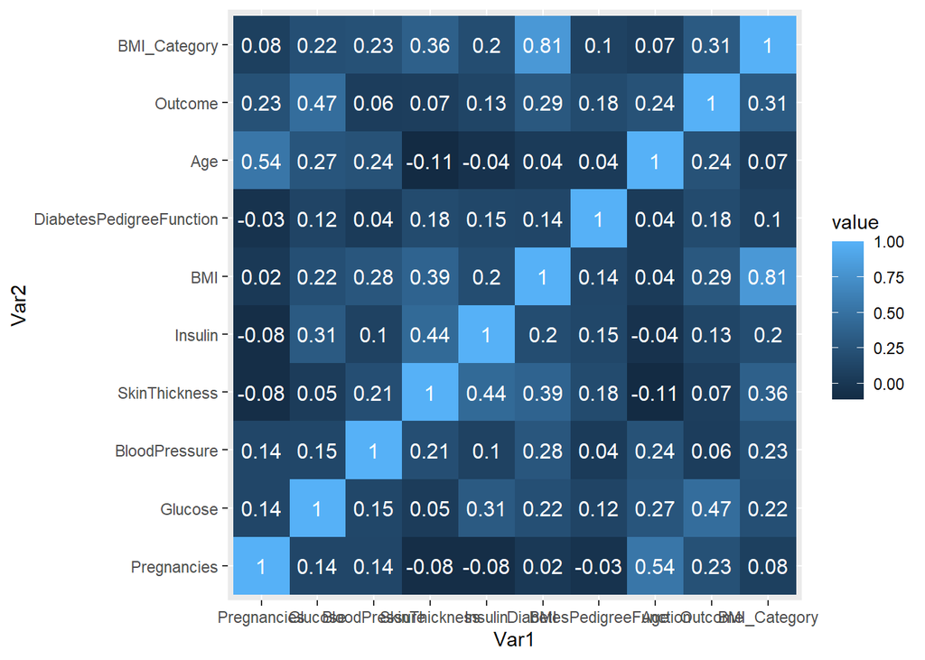

```r
library(lattice)
library(reshape2)

# creating correlation matrix
corr_mat <- round(cor(num_diabetes),2)

# reduce the size of correlation matrix
melted_corr_mat <- melt(corr_mat)
# head(melted_corr_mat)

# plotting the correlation heatmap
library(ggplot2)
ggplot(data = melted_corr_mat, aes(x=Var1, y=Var2, fill=value)) + geom_tile() +
  geom_text(aes(Var2, Var1, label = value), color = "white", size = 4)
```

## **Xây mô hình Random Forest để phân loại cân nặng**

### Chia dữ liệu thành huấn luyện và kiểm tra. 70% dành cho huấn luyện, 30% dành cho kiểm tra.

```r
set.seed(456)

samp <- sample(nrow(diabetes_filter), 0.7 * nrow(diabetes_filter))

train <- diabetes_filter[samp, ]

test <- diabetes_filter[-samp, ]
```

```r
#Kiểm tra kích thước của tập dữ liệu huấn luyện và kiểm tra
str(train)
```

```
## 'data.frame':    532 obs. of  10 variables:
##  $ Pregnancies             : int  7 8 1 0 12 7 7 8 0 5 ...
##  $ Glucose                 : int  137 194 84 119 92 136 161 196 93 115 ...
##  $ BloodPressure           : int  90 80 64 66 62 74 86 76 60 76 ...
##  $ SkinThickness           : int  41 0 23 27 7 26 0 29 0 0 ...
##  $ Insulin                 : int  0 0 115 0 258 135 0 280 0 0 ...
##  $ BMI                     : num  32 26.1 36.9 38.8 27.6 26 30.4 37.5 35.3 31.2 ...
##  $ DiabetesPedigreeFunction: num  0.391 0.551 0.471 0.259 0.926 0.647 0.165 0.605 0.263 0.343 ...
##  $ Age                     : int  39 67 28 22 44 51 47 57 25 44 ...
##  $ Outcome                 : int  0 0 0 0 1 0 1 1 0 1 ...
##  $ BMI_Category            : Factor w/ 4 levels "Underweight",..: 4 3 4 4 3 3 4 4 4 4 ...
```

```r
library(randomForest)
```

### Tìm giá trị tốt nhất cho tham số mtry bằng tuneRF

```
## mtry = 3  OOB error = 1.13%
## Searching left ...
## mtry = 2     OOB error = 2.07%
## -0.8333333 0.01
## Searching right ...
## mtry = 4     OOB error = 0.56%
## 0.5 0.01
## mtry = 6     OOB error = 0.38%
## 0.3333333 0.01
## mtry = 8     OOB error = 0%
## 1 0.01
```

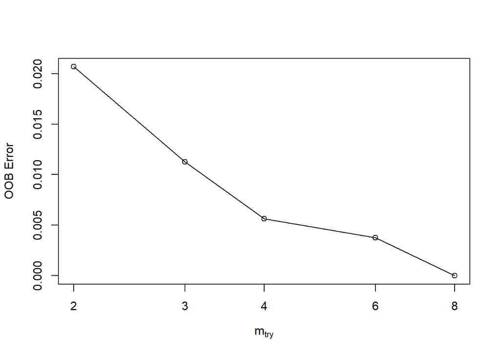

```r
rf_fit <- tuneRF(
  x = train[, 1:8],
  y = train[, 10],
  metric = "OOBAcc",
  ntreeTry = 100,
  mtryStart = 3,
  stepFactor = 1.5,
  improve = 0.01,
  trace = T,
  plot = T
)
```

### Tìm số cây trong rừng để mô hình cho kết quả tốt nhất với mtry = 3

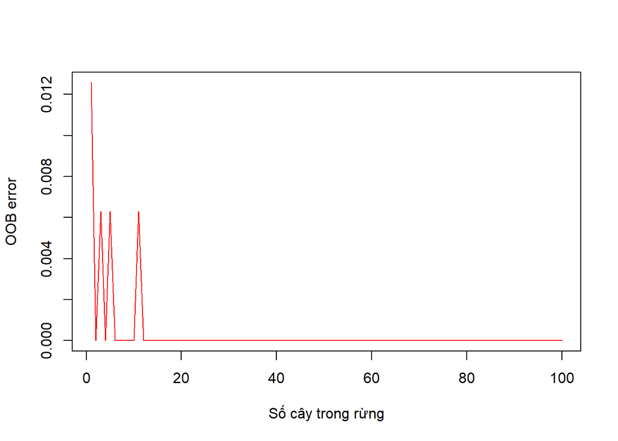

```r
# Lặp lại quá trình huấn luyện và đánh giá trên các giá trị khác nhau của ntree
error_out_of_bag <- c()

for (ntree in 1:100) {
    # Huấn luyện mô hình
    model <- randomForest(BMI_Category ~ . -Age -Pregnancies, data = train, ntree = ntree, mtry=3)

    # Tạo tập oob
    oob <- sample(nrow(train), 0.3 * nrow(train))

    # Tính lỗi out_of_bag
    error_out_of_bag[ntree] <- mean(predict(model, train[oob,]) != train[oob,]$BMI_Category)
}

# Vẽ đường cong lỗi
plot(error_out_of_bag, type = "l", col = "red", ylab = "OOB error", xlab="Số cây trong rừng")
```

### Huấn luyện mô hình

```r
model <- randomForest(BMI_Category ~ . -Age -Pregnancies, data = train, ntree = 100, mtry=3)
model
```

```
##
## Call:
##  randomForest(formula = BMI_Category ~ . - Age - Pregnancies,      data = train, ntree = 100, mtry = 3)
##                Type of random forest: classification
##                      Number of trees: 100
## No. of variables tried at each split: 3
##
##         OOB estimate of  error rate: 0.75%
## Confusion matrix:
##             Underweight Normal Overweight Obese class.error
## Underweight           7      3          0     0  0.30000000
## Normal                0     70          1     0  0.01408451
## Overweight            0      0        128     0  0.00000000
## Obese                 0      0          0   323  0.00000000
```

Ta có thể thấy:

- OOB error tỉ lệ số lần phân loại sai trên tập OOB ở các cây trong rừng, OOB error càng thấp thì độ chính xác càng cao
- class error là tỉ lệ phân loại sai ở các nhãn trên tập train đã tách OOB
- Các chỉ số trên có thể khác nhau ở mỗi lần train, vì tập OOB sẽ lấy ngẫu nhiên

### Xác thực mô hình của chúng tôi bằng cách sử dụng dữ liệu thử nghiệm

```r
prediction_test <- predict(model, newdata = test)
prediction_train <- predict(model, newdata = train)

table(prediction_train, train$BMI_Category)
```

```
##
## prediction_train Underweight Normal Overweight Obese
##      Underweight          10      0          0     0
##      Normal                0     71          0     0
##      Overweight            0      0        128     0
##      Obese                 0      0          0   323
```

```r
table(prediction_test, test$BMI_Category)
```

```
##
## prediction_test Underweight Normal Overweight Obese
##     Underweight           3      0          0     0
##     Normal                2     30          0     0
##     Overweight            0      0         51     0
##     Obese                 0      0          0   142
```

### Hiển thị giá trị dự đoán so với giá trị thực tế

```r
results<-cbind(prediction_test, test$BMI_Category)

head(results)
```

```
##    prediction_test
## 2                3 3
## 5                4 4
## 6                3 3
## 7                4 4
## 11               4 4
## 14               4 4
```

```r
colnames(results)<-c('pred','real')

results<-as.data.frame(results)

View(results)
```

### Tính độ chính xác của mô hình

```r
accuracy_test <- mean(prediction_test == test$BMI_Category)
accuracy_train <- mean(prediction_train == train$BMI_Category)

paste("độ chính xác trên tập train: ", accuracy_train)
```

```
## [1] "độ chính xác trên tập train:  1"
```

```r
paste("độ chính xác trên tập test: ", accuracy_test)
```

```
## [1] "độ chính xác trên tập test:  0.991228070175439"
```

Bạn có thể thấy rằng độ chính xác của mô hình này là khoảng 99-100 (%), điều này thật tuyệt vời. Bây giờ chúng tôi đã tự động hóa quá trình dự đoán loại cân nặng. Điều này đưa chúng ta đến khả năng theo dõi tình trạng sức khỏa của bệnh nhân và đưa ra chuẩn đoán sớm

## **kiểm định giả thuyết thống kế**

### để chứng minh phần trăm mỡ trong cơ thẻ cũng ảnh hướng đến việc có mắc bệnh hay không

### *Cách 1: One-Sample T-test*

### giả thuyết BMI (Chỉ số khối cơ thể) trung bình 34 dễ mắc bệnh tiểu đường

```r
library(knitr)
```

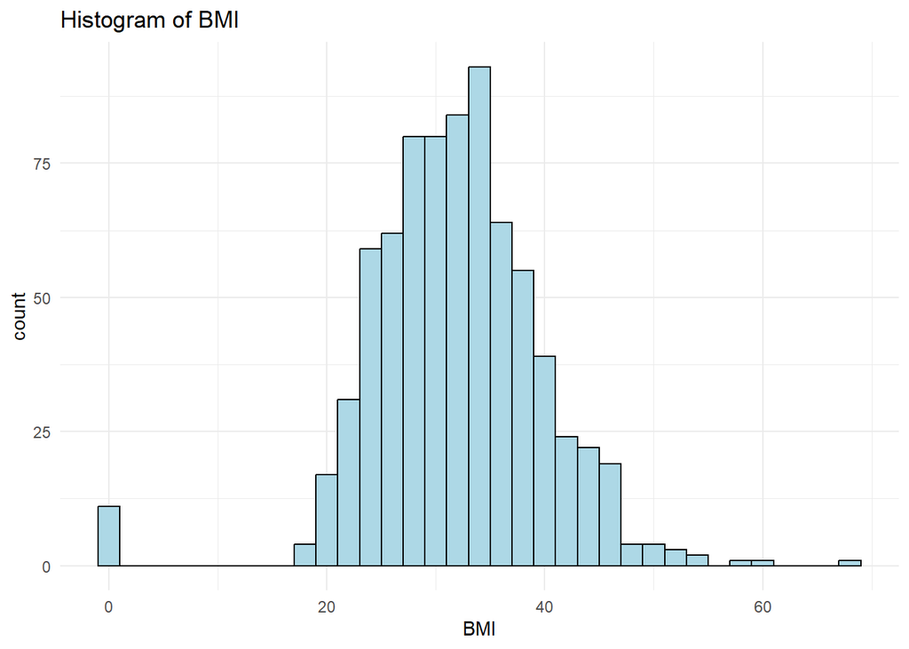

```r
# Vẽ biểu đồ histogram
ggplot(diabetes_filter, aes(x = BMI)) +
  geom_histogram(binwidth = 2, fill = "lightblue", color = "black") +
  labs(x = "BMI", title = "Histogram of BMI") + theme_minimal()
```

```r
# summary statistics
kable(summary(select(diabetes_filter, BMI)), format = "markdown")
```

|  | BMI |
| --- | --- |
|  | Min. : 0.00 |
|  | 1st Qu.:27.30 |
|  | Median :32.00 |
|  | Mean :31.96 |
|  | 3rd Qu.:36.52 |
|  | Max. :67.10 |

### Giả thuyết BMI trung bình mắc bệnh tiểu đường là 34

$$H_0: bmi = 34$$

$$H_a: bmi \neq 34$$

$$t = \frac{\bar{x} - \mu_0}{s/\sqrt{n}} \\
\bar{x} \text{: là giá trị trung bình của mẫu.} \\
\mu_0 \text{: là giá trị trung bình đã biết đến hoặc giả định.} \\
s \text{: là độ lệch chuẩn của mẫu.} \\
n \text{: là kích thước mẫu.} \\$$

```r
# Tính độ lệch chuẩn của mẫu dữ liệu
standard_deviation <- sd(diabetes_filter$BMI)
print(standard_deviation)
```

```
## [1] 7.902608
```

```r
t.test(num_diabetes[num_diabetes$Outcome==1,6], mu=34)
```

```
##
##  One Sample t-test
##
## data:  num_diabetes[num_diabetes$Outcome == 1, 6]
## t = 2.4563, df = 263, p-value = 0.01469
## alternative hypothesis: true mean is not equal to 34
## 95 percent confidence interval:
##  34.21895 35.98862
## sample estimates:
## mean of x
##  35.10379
```

#### Kết luận và giải thích

- Từ đầu ra và từ p.value chúng ta thấy rằng
- p-value nhỏ mức ý nghĩa 5%.
- Giống như bất kỳ bài kiểm tra thống kê nào khác , nếu p-value nhỏ hơn mức ý nghĩa thì có thể bác bỏ giả thuyết. –> Dựa vào kết quả kiểm định t-test, có thể kết luận rằng giá trị trung bình thực sự của cột “BMI” không bằng 34, và Ước lượng trung bình của mẫu có thể nằm trong khoảng từ 34.21895 đến 35.98862 với mức tin cậy 95%.

# ——————————————-

## **Cách 2: Independent Samples T-test**

#### **để chứng minh phần trăm mỡ trong cơ thẻ cũng ảnh hướng đến việc có mắc bệnh hay không**

### giả thuyết lượng mỡ trong cơ thể (BMI) không ảnh hưởng đến việc có bệnh hay không**

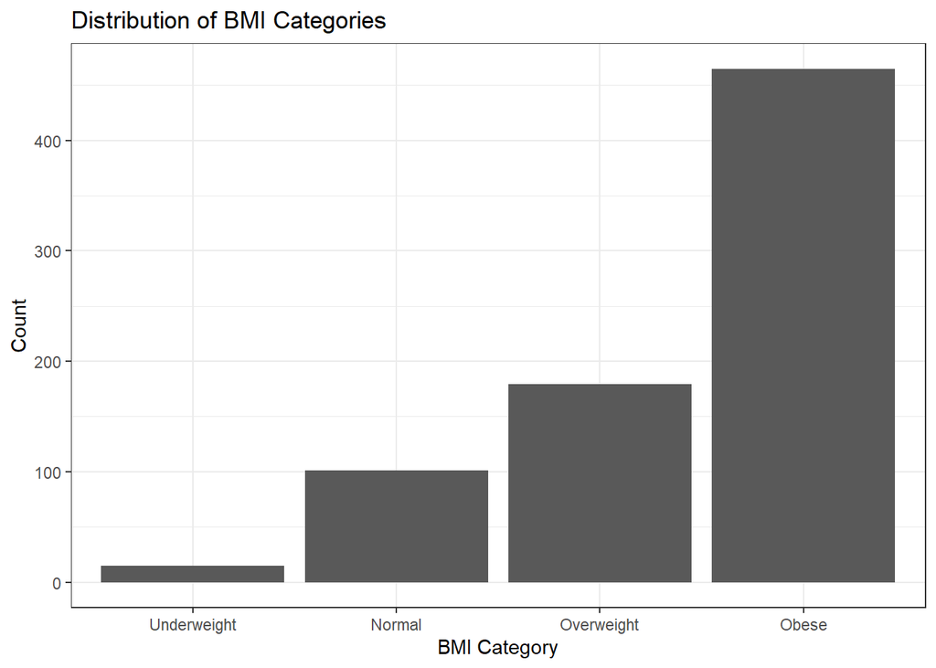

```r
# Vẽ biểu đồ histogram
ggplot(diabetes_filter, aes(x = BMI_Category)) +
  geom_bar(stat = "count") +
  labs(title = "Distribution of BMI Categories", x = "BMI Category", y = "Count") +
  theme_bw()
```

### Giả thuyết tỳ lệ BMI của người bệnh và không bệnh là như nhau

$$H_0: bmi_0 = bmi_1$$

$$H_a: bmi_0 \neq bmi_1$$

$$t = \frac{\bar{x}_A - \bar{x}_B}{\sqrt{\frac{s_A^2}{n_A} +
\frac{s_B^2}{n_B}}} \\
(\bar{x}_A) \text{: là giá trị trung bình của nhóm A.} \\
(\bar{x}_B) \text{: là giá trị trung bình của nhóm B.} \\
(s_A) \text{: là độ lệch chuẩn của nhóm A.} \\
(s_B) \text{: là độ lệch chuẩn của nhóm B.} \\
(n_A) \text{: là kích thước của nhóm A.} \\
(n_B) \text{: là kích thước của nhóm B.} \\$$

```r
#lấy ra những người bệnh và không bệnh có chỉ số BMI_Category >= 3
sick <- num_diabetes[num_diabetes$Outcome==1 & num_diabetes$BMI_Category >= 3,6]
normal <- num_diabetes[num_diabetes$Outcome==0 & num_diabetes$BMI_Category >= 3,6]
length(sick)
```

```
## [1] 255
```

```r
length(normal)
```

```
## [1] 389
```

```r
# Tính độ lệch chuẩn của mỗi mẫu dữ liệu
sa <- sd(sick)
print(sa)
```

```
## [1] 6.447191
```

```r
sb <- sd(normal)
print(sb)
```

```
## [1] 5.58764
```

```r
# Kiểm tra đồng nhất về phương sai
result <- var.test(sick, normal)
print(result)
```

```
##
##  F test to compare two variances
##
## data:  sick and normal
## F = 1.3313, num df = 254, denom df = 388, p-value = 0.01127
## alternative hypothesis: true ratio of variances is not equal to 1
## 95 percent confidence interval:
##  1.066823 1.670255
## sample estimates:
## ratio of variances
##           1.331325
```

```r
t.test(normal,sick,var.equal=FALSE)
```

```
##
##  Welch Two Sample t-test
##
## data:  normal and sick
## t = -5.5659, df = 488.23, p-value = 4.307e-08
## alternative hypothesis: true difference in means is not equal to 0
## 95 percent confidence interval:
##  -3.714332 -1.776138
## sample estimates:
## mean of x mean of y
##  32.94653  35.69176
```

#### Kết luận và giải thích

- Từ đầu ra và từ p.value chúng ta thấy rằng
- p-value nhỏ hơn mức ý nghĩa 5%.
- Giống như bất kỳ bài kiểm tra thống kê nào khác , nếu p-value nhỏ hơn mức ý nghĩa thì có thể bác bỏ giả thuyết. –> Dựa vào kết quả kiểm định t-test, có thể kết luận rằng lượng mỡ trong cơ thể có ảnh hưởng đến việc người đó có bệnh tiểu đường .

## *để chứng minh độ tuổi cũng ảnh hưởng đến việc người đó có bị bệnh tiểu đường hay không.*

### giả thuyết độ tuổi trung bình mắc bệnh tiểu đường là 35

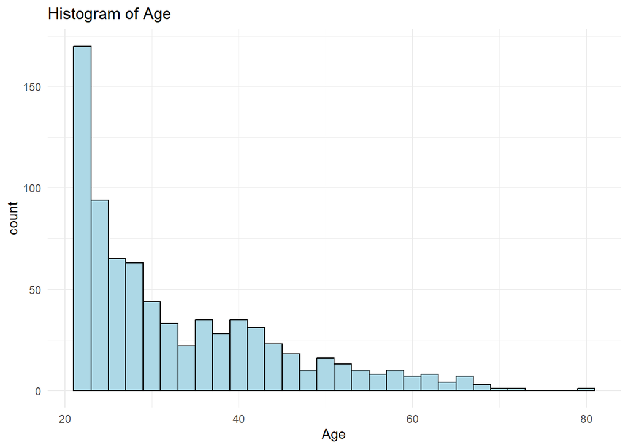

```r
# Vẽ biểu đồ histogram
ggplot(num_diabetes, aes(x = Age)) +
  geom_histogram(binwidth = 2, fill = "lightblue", color = "black") +
  labs(x = "Age", title = "Histogram of Age") +
  theme_minimal()
```

```r
# summary statistics
kable(summary(select(diabetes, Age)), format = "markdown")
```

|  | Age |
| --- | --- |
|  | Min. :21.00 |
|  | 1st Qu.:24.00 |
|  | Median :29.00 |
|  | Mean :33.24 |
|  | 3rd Qu.:41.00 |
|  | Max. :81.00 |

###giả thuyết độ tuổi trung bình mắc bệnh tiểu đường là 35

$$H_0: age = 35$$

$$H_a: age \neq 35$$

```r
t.test(num_diabetes[num_diabetes$Outcome==1,8], mu=35)
```

```
##
##  One Sample t-test
##
## data:  num_diabetes[num_diabetes$Outcome == 1, 8]
## t = 3.1548, df = 263, p-value = 0.001793
## alternative hypothesis: true mean is not equal to 35
## 95 percent confidence interval:
##  35.80157 38.46359
## sample estimates:
## mean of x
##  37.13258
```

#### Kết luận và giải thích

- Từ đầu ra và từ p.value chúng ta thấy rằng
- p-value nhỏ mức ý nghĩa 5%.
- Giống như bất kỳ bài kiểm tra thống kê nào khác , nếu p-value nhỏ hơn mức ý nghĩa thì có thể bác bỏ giả thuyết không. –> Dựa vào kết quả kiểm định t-test, có thể kết luận rằng giá trị trung bình thực sự của cột “Age” không bằng 35, và Ước lượng trung bình của mẫu có thể nằm trong khoảng từ 35.80157 đến 38.46359 với mức tin cậy 95%.